# Assignment 6

Jiaming Xu

# Q1:

.open /Users/Downloads/imdb.db .tables CREATE TABLE director_info( Director_ID PRIMARY KEY, Director_Name TEXT); .tables .separator ‘,’ .import /Users/Downloads/directors.csv director_info SELECT * FROM director_info .save /Users/Downloads/imdb2.db

# Q2:

## 1.

```r
library(RSQLite)
library(ggplot2)
library(dplyr)
```

1. Use dbConnect to load database into R.
2. Check talbes in database, create two sqlCmd strings.
3. Use dbGetQuery function to directly get results by running sqlCmd from database.
4. print results.

```r
con <- dbConnect(SQLite(), "/Users/jiamingxu/Downloads/imdb2.db")
dbListTables(con)
```

```
## [1] "director_info" "movie_info"
```

```r
sqlCmd1 = "SELECT COUNT(*) FROM movie_info"
sqlCmd2 = "SELECT COUNT(*) FROM director_info"

rs1 = dbGetQuery(con, sqlCmd1)
rs2 = dbGetQuery(con, sqlCmd2)
sprintf("movie_info has %d of rows, director_info has %d of rows", as.integer(rs1), as.integer(rs2))
```

```
## [1] "movie_info has 1000 of rows, director_info has 548 of rows"
```

## 2.

1. Create sqlCmd string with two variables x and y referring years.
2. Use Query function ot send a qurey to sqlite.
3. Use dbBind function to add parameters.
4. Fetch results and print.
5. Show histogram plot for visulization.

```r
sqlCmd = "SELECT COUNT(*) AS 'Summation' FROM movie_info WHERE Release_Year >= :x AND Release_Year <= :y"
query = dbSendQuery(con, sqlCmd)
dbBind(query, params = list(x = 2010, y = 2020))
rs = dbFetch(query)
print(rs)
```

```
##   Summation
## 1       225
```

```r
sqlCmd = "SELECT Release_Year FROM  movie_info;"
rs = dbGetQuery(con, sqlCmd)
```

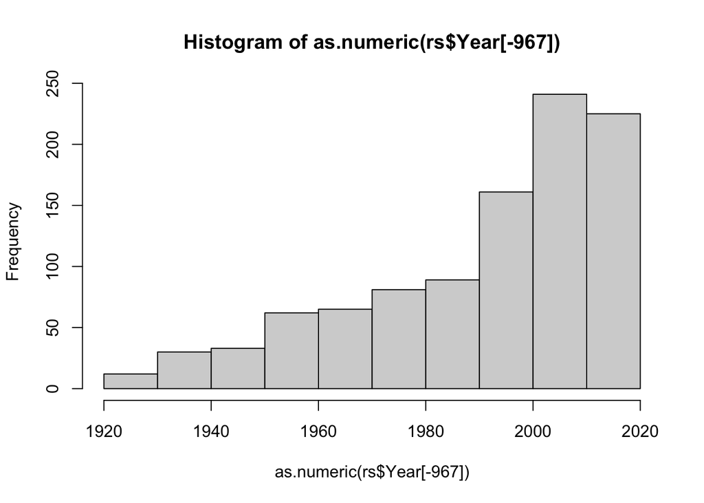

```r
rs <- as_tibble(rs)
colnames(rs) <- c("Year","Count")
# Drop invalid year info.
hist(as.numeric(rs$Year[-967]))
```

## 3:

1. Use “%Action%” string to screen out action movies.
2. Use min, max, mean functions in R to process these results.
3. We can also do data process in sql, but covered by future questions.

```r
sqlCmd = "SELECT IMDB_Rating FROM movie_info WHERE Genre LIKE '%Action%'"
rs <- dbGetQuery(con, sqlCmd)
sprintf("Acting movies Min rating is %.2f, Max rating is %.2f, average rating is %.2f.",min(rs), max(rs), mean(rs$IMDB_Rating))
```

```
## [1] "Acting movies Min rating is 7.60, Max rating is 9.00, average rating is 7.95."
```

## 4:

1. Use !=“NA” string to screen out empty rows in Gross column.
2. Use ORDER BY .. DESC to sort results descending. LIMIT first 25 results.

```r
sqlCmd = "SELECT Series_Title, Genre, Gross FROM movie_info WHERE Gross != 'NA' ORDER BY Gross DESC LIMIT 25 ;"
rs <- dbGetQuery(con, sqlCmd)
print(rs)
```

```
##                                     Series_Title                        Genre
## 1     Star Wars: Episode VII - The Force Awakens    Action, Adventure, Sci-Fi
## 2                              Avengers: Endgame     Action, Adventure, Drama
## 3                                         Avatar   Action, Adventure, Fantasy
## 4                         Avengers: Infinity War    Action, Adventure, Sci-Fi
## 5                                        Titanic               Drama, Romance
## 6                                   The Avengers    Action, Adventure, Sci-Fi
## 7                                  Incredibles 2 Animation, Action, Adventure
## 8                                The Dark Knight         Action, Crime, Drama
## 9                                      Rogue One    Action, Adventure, Sci-Fi
## 10                         The Dark Knight Rises            Action, Adventure
## 11                    E.T. the Extra-Terrestrial               Family, Sci-Fi
## 12                                   Toy Story 4 Animation, Adventure, Comedy
## 13                                 The Lion King  Animation, Adventure, Drama
## 14                                   Toy Story 3 Animation, Adventure, Comedy
```

[output cut: 37 more lines]

## 5:

1. Use LEFT JOIN function join movie_info and director_info together, ON Director_ID.
2. SUM() function and AS to calculate the sum of Gross of each director, ORDRE BY .. DESC to sort results descending. LIMIT :x, variable defined in dbBind function.

```r
sqlCmd = "SELECT director_info.Director_Name, SUM(Gross) AS 'OVERALL' FROM movie_info LEFT JOIN director_info ON director_info.Director_ID = movie_info.Director_ID GROUP BY movie_info.Director_ID ORDER BY OVERALL DESC LIMIT :x;"
query = dbSendQuery(con, sqlCmd)
dbBind(query, params = list(x = 10))
rs = dbFetch(query)
print(rs)
```

```
##        Director_Name    OVERALL
## 1   Steven Spielberg 2478133165
## 2      Anthony Russo 2205039403
## 3  Christopher Nolan 1937454106
## 4      James Cameron 1748236602
## 5      Peter Jackson 1597312443
## 6        J.J. Abrams 1423170905
## 7          Brad Bird 1099627795
## 8    Robert Zemeckis 1049446456
## 9        David Yates  978953721
## 10       Pete Docter  939382131
```

## 6:

1. Find the input in Director_NAME in director_info, if not, return not found results. This is an easy way.
2. I still LEFT JOIN two tables first then looking up for the movie information, which can be modified to versatile purpose.

```r
verifyDirector <- function(x){
  sqlCmd = "SELECT * FROM director_info LEFT JOIN movie_info ON movie_info.Director_ID = director_info.Director_ID WHERE director_info.Director_Name = :w;"
  query = dbSendQuery(con, sqlCmd)
  dbBind(query, params = list(w = x))
  rs = dbFetch(query)
  if(nrow(rs) == 0){sprintf("%s is not found in database", x)} else{
    sprintf("%s is found in database", x)
  }
}
verifyDirector("David Li")
```

```
## [1] "David Li is not found in database"
```

```r
verifyDirector("Steven Spielberg")
```

```
## [1] "Steven Spielberg is found in database"
```

# Q3:

```r
sqlCmd = "SELECT avg(Runtime) FROM movie_info WHERE Genre LIKE '%thriller%';"
rs <- dbGetQuery(con, sqlCmd)
print(rs)
```

```
##   avg(Runtime)
## 1     119.6423
```

```r
dbDisconnect(con)
```